# 615 Final Project Presentation

12/9/2017

## 1. Motivation

In this project, I discuss Twitter activity that relates to Starbucks. Starbucks is the biggest American coffee company and coffeehouse chain. One of the important reason that I choose Starbucks as my topic is that Starbucks utilized the mobile platform to launch the "Tweet-a-Coffee" promotion in October 2013. On this occasion, the promotion also involved Twitter and customes were able to purchase a $5 gift card for a friend by entering both "@tweetacoffee" and the friend's handle in a tweet. Therefore, I think the Twitter activity that about Starbucks would increased rapidly since then.

## 2. Map

### a. Map of number of tweets

First of all, this is the map where each point represents the number of tweets in the circle of radius equals 100 miles that centered in that point. And I want to explore people in which area prefer to express their feelings about Starbucks. The lighter the point, the greater number of tweets appear in that area.

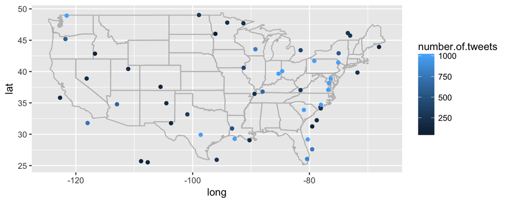

## 2.Map

### a. Map of number of tweets

According to the map we can see that most of the light points ditributed in east coast, Texas and Carlifonia, and there are mainly dark blue points in the middle area. This plot coincides with the fact that most of the big cities are locateded in east coast (e.g. Boston, NYC, Orlando etc) and west coast where there are more Starbucks coffeehouse.

## 2.Map

### b. Geolocation Density Map

Secondly, the desity plot shows the level of density in the map. The darker the area, the higher tweets density in that area.

[figure not shown]

## 2.Map

### b. Geolocation Density Map

According to the plot, we can get the similar result at in Map(a). The tweets posted density in east is the highest across the country. The maps indicate that people live in east part (or big cities), and then California and middle east part prefer using Twitter to express their feelings about Starbucks. The reason of this might be there are more Starbucks coffeehouse in these area and people live in big cities would love to use social media to share their daily lives with others.

## 3. Emoji Analysis

### a. Rank of the frequently used emojis

Firstly, the following is a bar chart presents the top 10 emojis in tweets relates to Starbucks.

[figure not shown]

## 3. Emoji Analysis

### a. Rank of the frequently used emojis

From the plot we can see that most of the frequently used emojis are about beverage, joy, christmas and love, which means starbucks usually bring people happiness. To get the exact proportion of positive and negative attitude towards Starbucks, I will do a sentiment analysis in later part.

## 3. Emoji Analysis

### b. Top emoji scatterplot

The next step after visualizing the top emojis is to compare emoji frequency between two different subsets of the data. We can use custom annotations to plot log odds ratios and overall densities on an x-y plane.

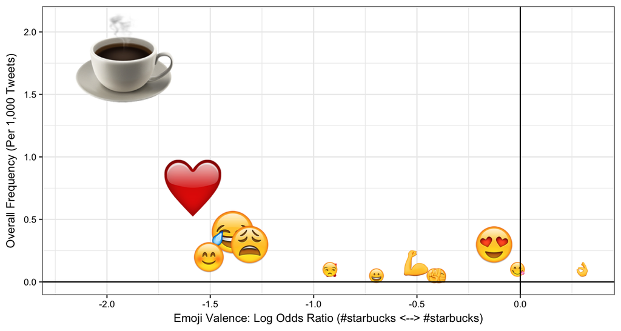

## 4. Text Mining

### a. Word Frequency

In exploring the most frequently used words when people post tweets about Starbucks, the text variable is used in the dataset. Firstly, the following is the bar chart that pick the words that appear more than 900 times.

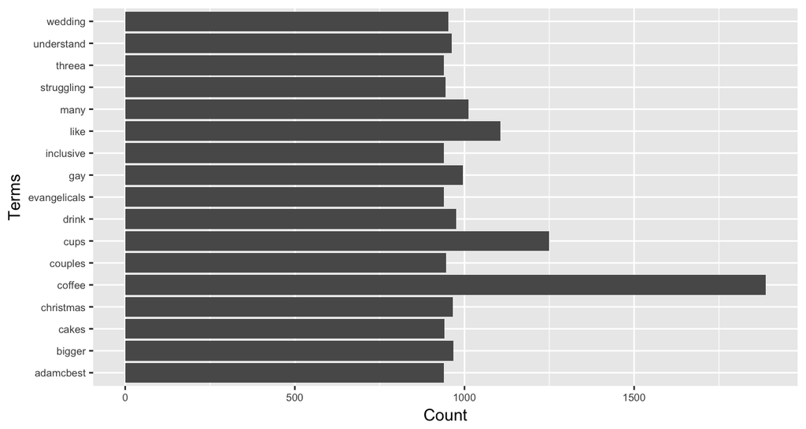

### a. Word Frequency

The result of the bar chart is pretty intuitive. "Coffee" appears more than 1800 times which is much greater than other words. Then the second and third words are "cups" and "like". We can see that the top three frequently used words are all relavent to Starbucks and "like" may used to express positive sentiment towards Starbucks.

## 4. Text Mining

### b. Word Cloud

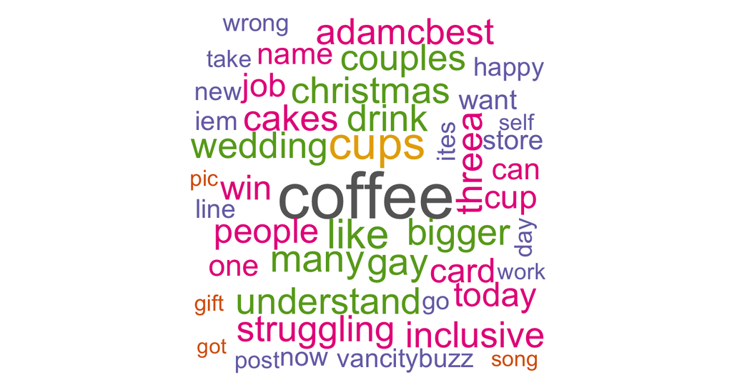

## 4. Text Mining

### c. Sentiment Analysis

### (1). Sentiment Score

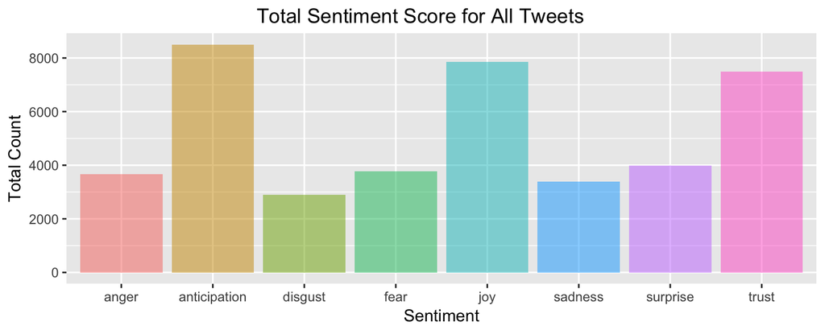

## c. Sentiment Analysis

### (1). Sentiment Score

"Total Sentiment Score of all Tweets" shows the difference in number of eight emotions based on all the tweets twxt in the US. We notice that that all of the top three emotions are positive emotions. The height of other five emotions which are anger, disgust, sadness,fear and surprise are close to each other but surprise is a little bit higher than other four negative emotions. Therefore, we can conclude that there are more Twitter users that hold a postive attitude towards Starbucks.

## 4. Text Mining

### c. Sentiment Analysis

### (2). Proportion of postive and negative

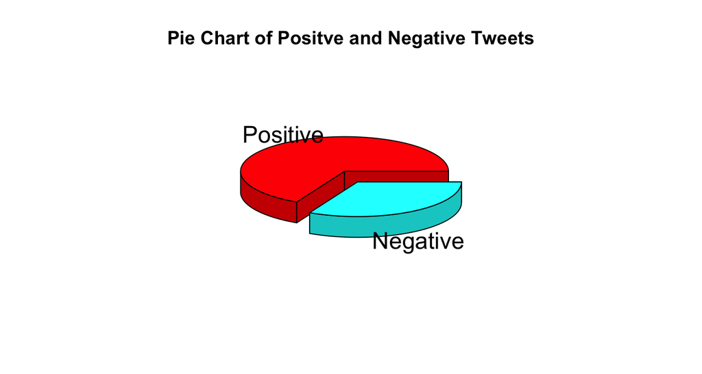

## 5. Clustering

Two methods are developed here to do clustering analysis. The first method is the K-Means clusting. This method aims to partition the n observations into k sets so as to minimize the within-cluster sum of squares. Second on is called hierarchical clustering.

### a. K-Means Clustering

```
## cluster1: now coffee can christmas new
## cluster2: coffee cups like many gay
## cluster3: coffee day go drink cup
## cluster4: want work job go now
## cluster5: win card enter starbuckscanada gift
```

Setting k equals to five gives us five clusters. From the clustering result we can see that the words within each group are somewhat similar to each other.

## 5. Clustering

### b. Hierarchical Clustering

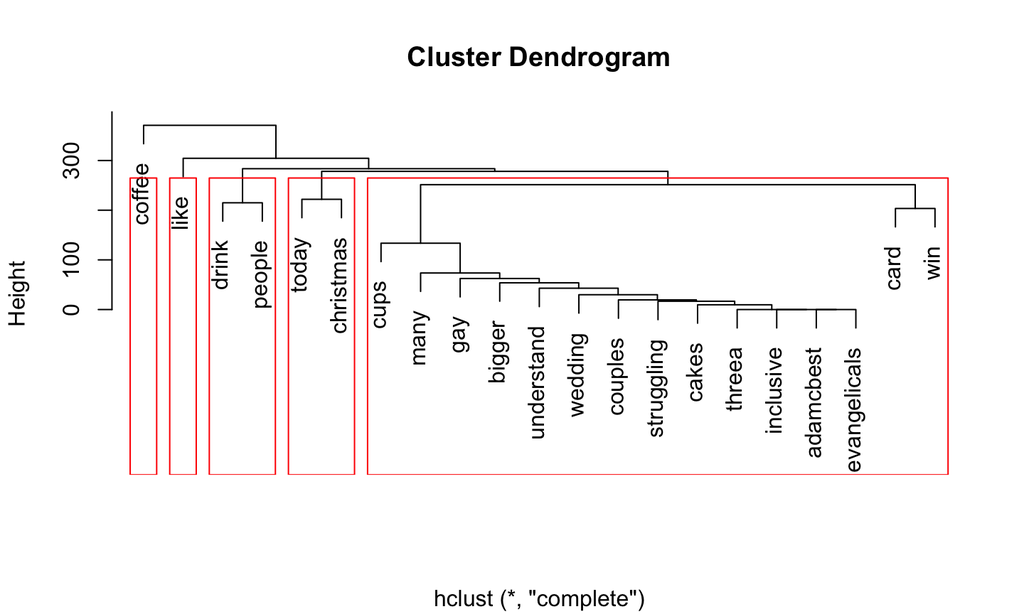

## 5. Clustering

### b. Hierarchical Clustering

In this part, I use hclust function and adopt the complete method to do the hierarchical clustering.To compare the two clustering methods, I also divide those words into five group. The clustering results by the two methods are not exactly the same but both give us reasonable clusters.

## 6. Shinyapp

My Shinyapp website: https://keer.shinyapps.io/final2/